# Stats Example

Lauren Gardiner

2017-09-11

# Setup

Get data

```r
data(mtcars)
head(mtcars)
```

```
##                    mpg cyl disp  hp drat    wt  qsec vs am gear carb
## Mazda RX4         21.0   6  160 110 3.90 2.620 16.46  0  1    4    4
## Mazda RX4 Wag     21.0   6  160 110 3.90 2.875 17.02  0  1    4    4
## Datsun 710        22.8   4  108  93 3.85 2.320 18.61  1  1    4    1
## Hornet 4 Drive    21.4   6  258 110 3.08 3.215 19.44  1  0    3    1
## Hornet Sportabout 18.7   8  360 175 3.15 3.440 17.02  0  0    3    2
## Valiant           18.1   6  225 105 2.76 3.460 20.22  1  0    3    1
```

# Basic Stats

Calculate summary statistics

```r
mean(mtcars$mpg)
```

```
## [1] 20.09062
```

```r
summary(mtcars$mpg)
```

```
##    Min. 1st Qu.  Median    Mean 3rd Qu.    Max.
##   10.40   15.43   19.20   20.09   22.80   33.90
```

Create a simple table

```r
table(mtcars$gear)
```

```
##
##  3  4  5
## 15 12  5
```

Create a table with two variables

```r
table(mtcars$gear, mtcars$am)
```

```
##
##      0  1
##   3 15  0
##   4  4  8
##   5  0  5
```

Create a table with more than two variables

```r
ftable(mtcars$gear, mtcars$am, mtcars$cyl)
```

```
##       4  6  8
##
## 3 0   1  2 12
##   1   0  0  0
## 4 0   2  2  0
##   1   6  2  0
## 5 0   0  0  0
##   1   2  1  2
```

Create a proportion table

```r
prop.table(table(mtcars$gear))
```

```
##
##       3       4       5
## 0.46875 0.37500 0.15625
```

```r
mtcars %>%
  group_by(gear) %>%
  summarize(mean(mpg),
            mean(hp))
```

# Correlation

Calculate correlation between two variables

```r
cor(mtcars$mpg, mtcars$disp)
```

```
## [1] -0.8475514
```

Calculate pairwise correlation for an entire dataframe

```r
cor(mtcars)
```

```
##             mpg        cyl       disp         hp        drat         wt
## mpg   1.0000000 -0.8521620 -0.8475514 -0.7761684  0.68117191 -0.8676594
## cyl  -0.8521620  1.0000000  0.9020329  0.8324475 -0.69993811  0.7824958
## disp -0.8475514  0.9020329  1.0000000  0.7909486 -0.71021393  0.8879799
## hp   -0.7761684  0.8324475  0.7909486  1.0000000 -0.44875912  0.6587479
## drat  0.6811719 -0.6999381 -0.7102139 -0.4487591  1.00000000 -0.7124406
## wt   -0.8676594  0.7824958  0.8879799  0.6587479 -0.71244065  1.0000000
## qsec  0.4186840 -0.5912421 -0.4336979 -0.7082234  0.09120476 -0.1747159
## vs    0.6640389 -0.8108118 -0.7104159 -0.7230967  0.44027846 -0.5549157
## am    0.5998324 -0.5226070 -0.5912270 -0.2432043  0.71271113 -0.6924953
## gear  0.4802848 -0.4926866 -0.5555692 -0.1257043  0.69961013 -0.5832870
## carb -0.5509251  0.5269883  0.3949769  0.7498125 -0.09078980  0.4276059
##             qsec         vs          am       gear        carb
## mpg   0.41868403  0.6640389  0.59983243  0.4802848 -0.55092507
## cyl  -0.59124207 -0.8108118 -0.52260705 -0.4926866  0.52698829
## disp -0.43369788 -0.7104159 -0.59122704 -0.5555692  0.39497686
## hp   -0.70822339 -0.7230967 -0.24320426 -0.1257043  0.74981247
## drat  0.09120476  0.4402785  0.71271113  0.6996101 -0.09078980
## wt   -0.17471588 -0.5549157 -0.69249526 -0.5832870  0.42760594
## qsec  1.00000000  0.7445354 -0.22986086 -0.2126822 -0.65624923
## vs    0.74453544  1.0000000  0.16834512  0.2060233 -0.56960714
## am   -0.22986086  0.1683451  1.00000000  0.7940588  0.05753435
## gear -0.21268223  0.2060233  0.79405876  1.0000000  0.27407284
## carb -0.65624923 -0.5696071  0.05753435  0.2740728  1.00000000
```

Calculate covariance

```r
cov(mtcars)
```

```
##              mpg         cyl        disp          hp         drat
## mpg    36.324103  -9.1723790  -633.09721 -320.732056   2.19506351
## cyl    -9.172379   3.1895161   199.66028  101.931452  -0.66836694
## disp -633.097208 199.6602823 15360.79983 6721.158669 -47.06401915
## hp   -320.732056 101.9314516  6721.15867 4700.866935 -16.45110887
## drat    2.195064  -0.6683669   -47.06402  -16.451109   0.28588135
## wt     -5.116685   1.3673710   107.68420   44.192661  -0.37272073
## qsec    4.509149  -1.8868548   -96.05168  -86.770081   0.08714073
## vs      2.017137  -0.7298387   -44.37762  -24.987903   0.11864919
## am      1.803931  -0.4657258   -36.56401   -8.320565   0.19015121
## gear    2.135685  -0.6491935   -50.80262   -6.358871   0.27598790
## carb   -5.363105   1.5201613    79.06875   83.036290  -0.07840726
##               wt         qsec           vs           am        gear
## mpg   -5.1166847   4.50914919   2.01713710   1.80393145   2.1356855
## cyl    1.3673710  -1.88685484  -0.72983871  -0.46572581  -0.6491935
## disp 107.6842040 -96.05168145 -44.37762097 -36.56401210 -50.8026210
## hp    44.1926613 -86.77008065 -24.98790323  -8.32056452  -6.3588710
## drat  -0.3727207   0.08714073   0.11864919   0.19015121   0.2759879
## wt     0.9573790  -0.30548161  -0.27366129  -0.33810484  -0.4210806
## qsec  -0.3054816   3.19316613   0.67056452  -0.20495968  -0.2804032
## vs    -0.2736613   0.67056452   0.25403226   0.04233871   0.0766129
## am    -0.3381048  -0.20495968   0.04233871   0.24899194   0.2923387
## gear  -0.4210806  -0.28040323   0.07661290   0.29233871   0.5443548
## carb   0.6757903  -1.89411290  -0.46370968   0.04637097   0.3266129
##             carb
## mpg  -5.36310484
## cyl   1.52016129
## disp 79.06875000
## hp   83.03629032
## drat -0.07840726
## wt    0.67579032
## qsec -1.89411290
## vs   -0.46370968
## am    0.04637097
## gear  0.32661290
## carb  2.60887097
```

# t-test

Do automatic transmission cars have different mpg than manual transmission cars?

```r
t.test(mtcars$mpg[mtcars$am == 0], mtcars$mpg[mtcars$am == 1])
```

```
##
##  Welch Two Sample t-test
##
## data:  mtcars$mpg[mtcars$am == 0] and mtcars$mpg[mtcars$am == 1]
## t = -3.7671, df = 18.332, p-value = 0.001374
## alternative hypothesis: true difference in means is not equal to 0
## 95 percent confidence interval:
##  -11.280194  -3.209684
## sample estimates:
## mean of x mean of y
##  17.14737  24.39231
```

You can also use a formula format instead of passing two vectors of values

```r
t1 <- t.test(mtcars$mpg ~ mtcars$am)
names(t1)
```

```
## [1] "statistic"   "parameter"   "p.value"     "conf.int"    "estimate"
## [6] "null.value"  "alternative" "method"      "data.name"
```

You can pull out a specific value from the `t.test`

```r
t1$p.value
```

```
## [1] 0.001373638
```

# Linear Model

The typical format for a linear model is as follows:

```r
lm(y ~ x1 + x2 + x3, data=df)
```

Here is an example with our `mtcars` data:

```r
r1 <- lm(mpg ~ hp, data = mtcars)
summary(r1)
```

```
##
## Call:
## lm(formula = mpg ~ hp, data = mtcars)
##
## Residuals:
##     Min      1Q  Median      3Q     Max
## -5.7121 -2.1122 -0.8854  1.5819  8.2360
##
## Coefficients:
##             Estimate Std. Error t value Pr(>|t|)
## (Intercept) 30.09886    1.63392  18.421  < 2e-16 ***
## hp          -0.06823    0.01012  -6.742 1.79e-07 ***
## ---
## Signif. codes:  0 '***' 0.001 '**' 0.01 '*' 0.05 '.' 0.1 ' ' 1
##
## Residual standard error: 3.863 on 30 degrees of freedom
## Multiple R-squared:  0.6024, Adjusted R-squared:  0.5892
## F-statistic: 45.46 on 1 and 30 DF,  p-value: 1.788e-07
```

Model results and summary have different info

```r
names(r1)
```

```
##  [1] "coefficients"  "residuals"     "effects"       "rank"
##  [5] "fitted.values" "assign"        "qr"            "df.residual"
##  [9] "xlevels"       "call"          "terms"         "model"
```

```r
names(summary(r1))
```

```
##  [1] "call"          "terms"         "residuals"     "coefficients"
##  [5] "aliased"       "sigma"         "df"            "r.squared"
##  [9] "adj.r.squared" "fstatistic"    "cov.unscaled"
```

We can plot the model and use `identify` to label specific points (need to use `identify` in console or script instead of markdown)

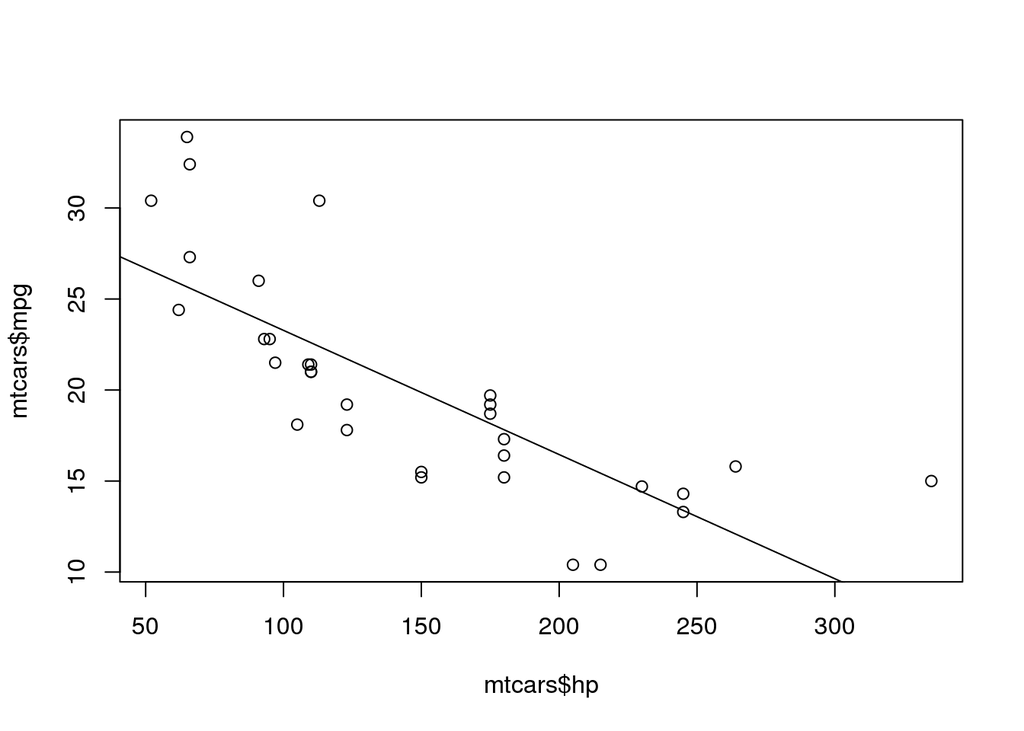

```
## integer(0)
```

```r
plot(mtcars$mpg ~ mtcars$hp)
abline(r1)
identify(mtcars$hp, mtcars$mpg, labels = rownames(mtcars))
```

The following command will show you four plots in the console

```r
plot(r1)
```

Create a second linear model

```r
r2 <- lm(mpg ~ hp + I(hp^2) + am + cyl, data=mtcars)
summary(r2)
```

```
##
## Call:
## lm(formula = mpg ~ hp + I(hp^2) + am + cyl, data = mtcars)
##
## Residuals:
##     Min      1Q  Median      3Q     Max
## -3.5346 -1.4905 -0.1394  1.4281  5.8274
##
## Coefficients:
##               Estimate Std. Error t value Pr(>|t|)
## (Intercept) 34.5193499  3.3413965  10.331 7.03e-11 ***
## hp          -0.1241475  0.0500586  -2.480   0.0197 *
## I(hp^2)      0.0002111  0.0001163   1.815   0.0806 .
## am           3.3892736  1.2783733   2.651   0.0133 *
## cyl         -0.5007040  0.7005650  -0.715   0.4809
## ---
## Signif. codes:  0 '***' 0.001 '**' 0.01 '*' 0.05 '.' 0.1 ' ' 1
##
## Residual standard error: 2.698 on 27 degrees of freedom
## Multiple R-squared:  0.8254, Adjusted R-squared:  0.7996
## F-statistic: 31.92 on 4 and 27 DF,  p-value: 7.088e-10
```

`poly` will give you each power up until the one specified, in this case 2.

```r
r2 <- lm(mpg ~ poly(hp, 2) + am + cyl, data=mtcars)
summary(r2)
```

```
##
## Call:
## lm(formula = mpg ~ poly(hp, 2) + am + cyl, data = mtcars)
##
## Residuals:
##     Min      1Q  Median      3Q     Max
## -3.5346 -1.4905 -0.1394  1.4281  5.8274
##
## Coefficients:
##              Estimate Std. Error t value Pr(>|t|)
## (Intercept)   21.8118     4.5903   4.752 5.94e-05 ***
## poly(hp, 2)1 -19.6109     6.1388  -3.195  0.00355 **
## poly(hp, 2)2   6.5986     3.6348   1.815  0.08059 .
## am             3.3893     1.2784   2.651  0.01325 *
## cyl           -0.5007     0.7006  -0.715  0.48092
## ---
## Signif. codes:  0 '***' 0.001 '**' 0.01 '*' 0.05 '.' 0.1 ' ' 1
##
## Residual standard error: 2.698 on 27 degrees of freedom
## Multiple R-squared:  0.8254, Adjusted R-squared:  0.7996
## F-statistic: 31.92 on 4 and 27 DF,  p-value: 7.088e-10
```

`-1` will remove the intercept. `I(factor(variable)) is used for categorical data

```r
r3 <- lm(mpg ~ -1 + poly(hp, 2) + am + I(factor(cyl)), data=mtcars)
summary(r3)
```

```
##
## Call:
## lm(formula = mpg ~ -1 + poly(hp, 2) + am + I(factor(cyl)), data = mtcars)
##
## Residuals:
##     Min      1Q  Median      3Q     Max
## -3.9796 -1.6906 -0.2307  1.3885  5.3339
##
## Coefficients:
##                 Estimate Std. Error t value Pr(>|t|)
## poly(hp, 2)1     -21.322      6.076  -3.509  0.00166 **
## poly(hp, 2)2       5.737      3.582   1.602  0.12128
## am                 3.676      1.258   2.922  0.00711 **
## I(factor(cyl))4   19.818      1.816  10.916 3.32e-11 ***
## I(factor(cyl))6   17.208      1.254  13.720 2.04e-13 ***
## I(factor(cyl))8   18.332      1.272  14.417 6.49e-14 ***
## ---
## Signif. codes:  0 '***' 0.001 '**' 0.01 '*' 0.05 '.' 0.1 ' ' 1
##
## Residual standard error: 2.627 on 26 degrees of freedom
## Multiple R-squared:  0.9872, Adjusted R-squared:  0.9843
## F-statistic: 334.7 on 6 and 26 DF,  p-value: < 2.2e-16
```

`*` allows you to have interaction terms

```r
r4 <- lm(mpg ~ hp*am, data=mtcars)
summary(r4)
```

```
##
## Call:
## lm(formula = mpg ~ hp * am, data = mtcars)
##
## Residuals:
##     Min      1Q  Median      3Q     Max
## -4.3818 -2.2696  0.1344  1.7058  5.8752
##
## Coefficients:
##               Estimate Std. Error t value Pr(>|t|)
## (Intercept) 26.6248479  2.1829432  12.197 1.01e-12 ***
## hp          -0.0591370  0.0129449  -4.568 9.02e-05 ***
## am           5.2176534  2.6650931   1.958   0.0603 .
## hp:am        0.0004029  0.0164602   0.024   0.9806
## ---
## Signif. codes:  0 '***' 0.001 '**' 0.01 '*' 0.05 '.' 0.1 ' ' 1
##
## Residual standard error: 2.961 on 28 degrees of freedom
## Multiple R-squared:  0.782,  Adjusted R-squared:  0.7587
## F-statistic: 33.49 on 3 and 28 DF,  p-value: 2.112e-09
```

Create a `termplot`

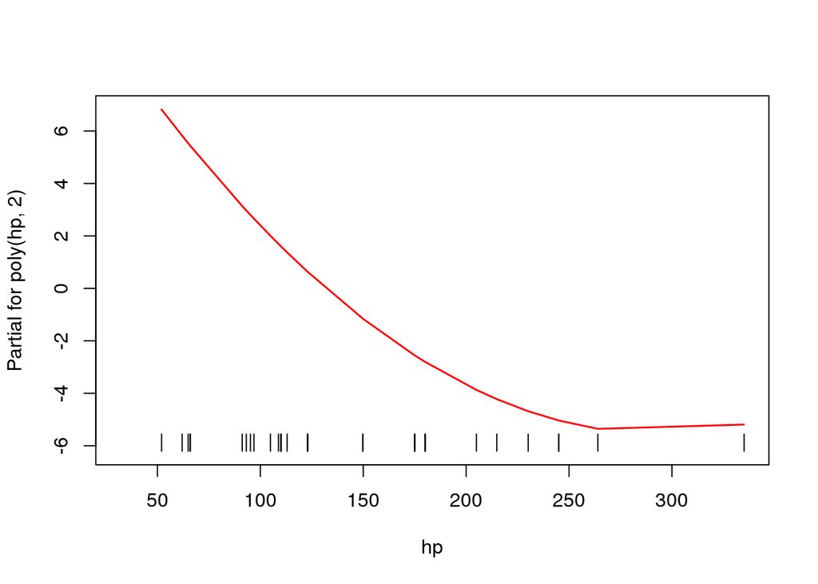

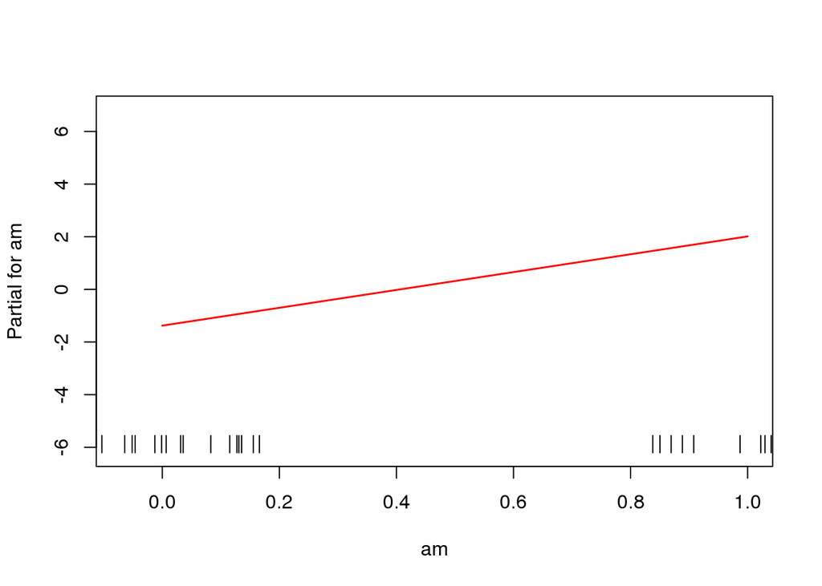

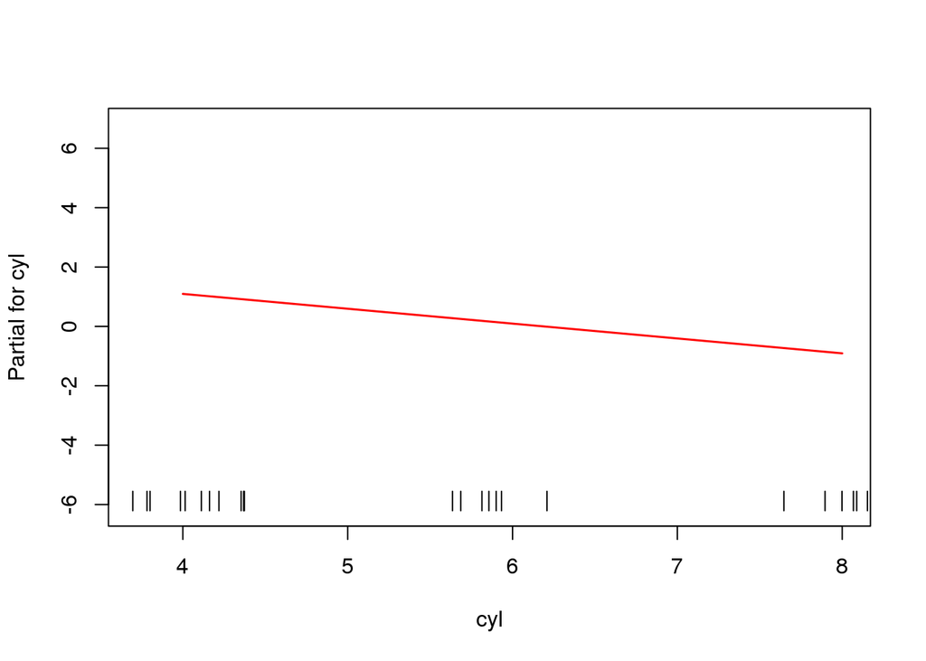

```r
termplot(r2, rug=TRUE)
```

Predict mpg values

```r
r4 <- lm(mpg ~ -1 + poly(hp, 2) + am + I(factor(cyl)), data=mtcars)
newvals <- data.frame(hp=seq(50, 250, 10),
                      am=0,
                      cyl=4)
mpg_predict <- predict(r4, newvals)
mpg_predict
```

```
##        1        2        3        4        5        6        7        8
## 27.01060 26.02120 25.06849 24.15250 23.27321 22.43063 21.62475 20.85558
##        9       10       11       12       13       14       15       16
## 20.12312 19.42737 18.76832 18.14597 17.56034 17.01141 16.49918 16.02367
##       17       18       19       20       21
## 15.58486 15.18275 14.81736 14.48867 14.19668
```

Visualize predicted values

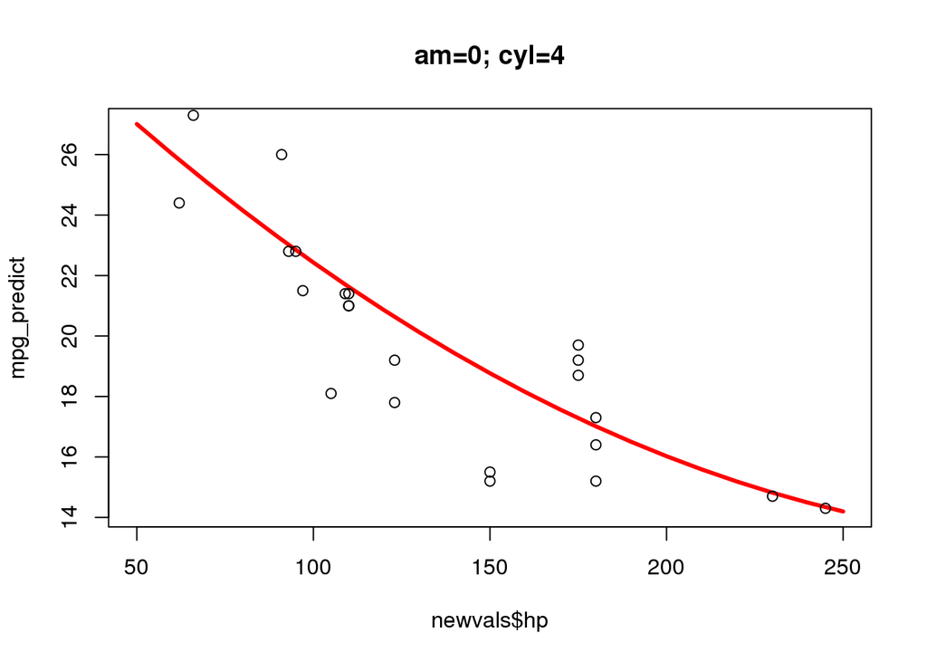

```r
plot(mpg_predict ~ newvals$hp,
     type="l", lwd=3, col="red",
     main="am=0; cyl=4")
points(mtcars$mpg ~ mtcars$hp)
```